# Implications of demographics on income

## Change in Median Income by Gender over years

How does the median income of Male and Female varies over the years?

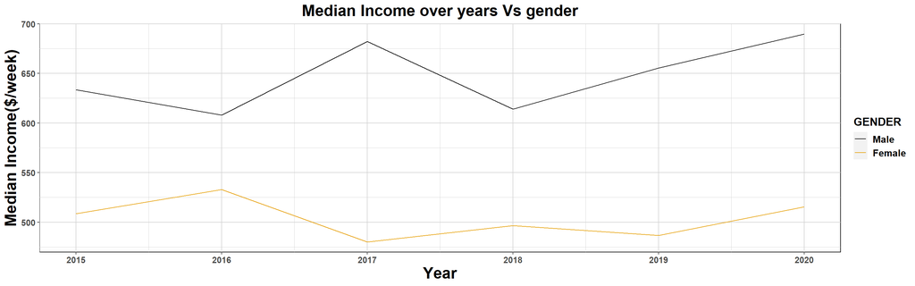

We see a substantial wage discrepancy between males and females, with females experiencing a significant drop in income throughout the 2016-2017 year. From 2016 to 2018, there was an increase followed by a fall for Males, and the weekly income has since been increasing, while the rate of increase for Females throughout the 2019-2020 period is fairly modest.

To fully comprehend the salary disparity between men and women, a more in-depth analysis is required, one that compares salaries depending on job location, demographics, and job description.

Is the above trend is seen across all the industries?

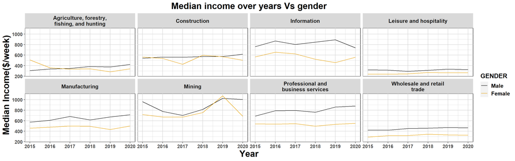

The wage gap between men and women is smaller in the agriculture, forestry, fishing, and hunting, construction, leisure and hospitality, and mining industries, but it is the largest in the information industry, followed by professional and business services, manufacturing, and wholesale and retail trade. As a result, the salary disparity isn’t a consistent trend across all industries.

## Change in Median Income by Race over years

How does the median income varies for different racial groups?

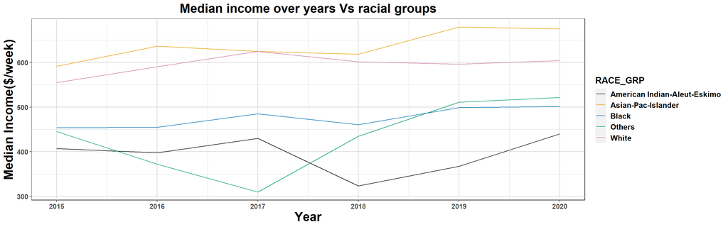

Do we see the same trend across all the industries?

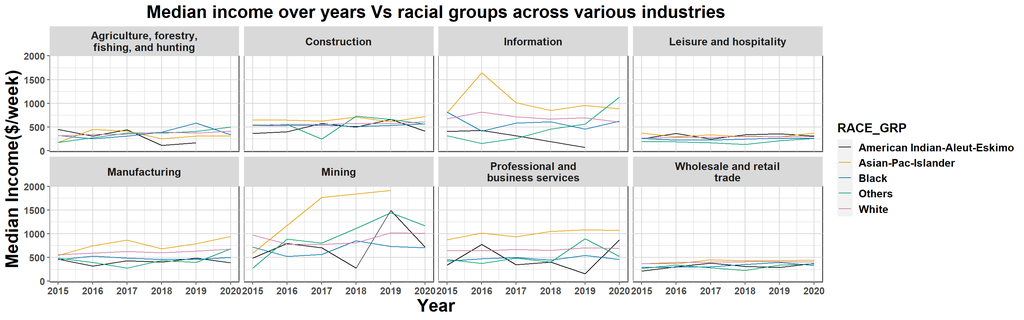

Asian-Pac-Islander group seems to be earning the most in Information, Manufacturing,Mining and Professional and business services industries, however, there is no significant different in other industries based on racial groups.

## Change in Median Income by Age over years

Under 18 age group has missing values in Construction industry and hence we remove the under 18 group from this analysis.

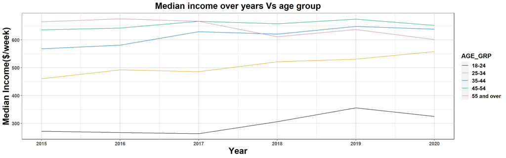

Do we see similar trend across all industries?

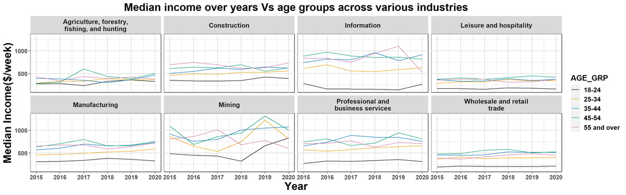

In contrast to the general trend, the 18-24 age group experienced a big salary gain in the mining industry and an increase in the information business, while they were unaffected in the Leisure and Hospitality and Wholesale and Retail trade industries. Wages in the information and mining industries plummeted for those aged 54 and over, while they fared better in Manufacturing, Construction, and Leisure and Hospitality.

## Change in Median Income by EDUC over years

Does attaining higher qualification helps one earn more?

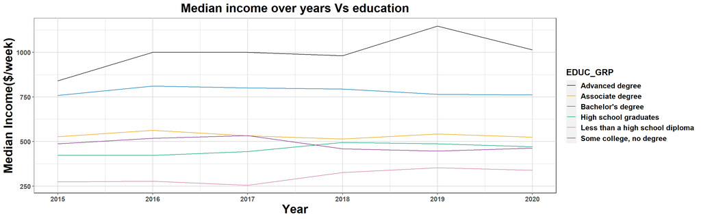

In general, highly qualified people earn more money than the rest of the population. People with advanced degrees, such as a Master’s or a Post-Doctoral degree, earn more than those with only a Bachelor’s degree. People with a high school diploma or less earn the least. In general, people with an Associate degree earn more money, but not nearly as much as those with a Bachelor’s degree or another advanced degree.

Does having a higher qualification helps earn in every industry?

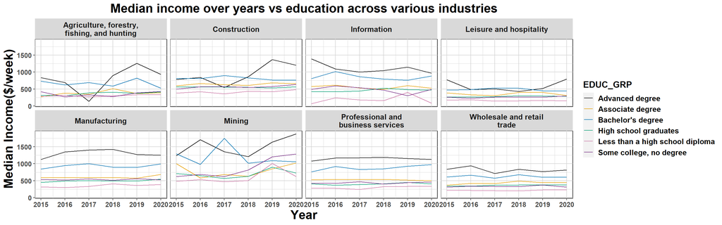

# Create a filtered dataset

Do Females earn less than Males across each racial groups?

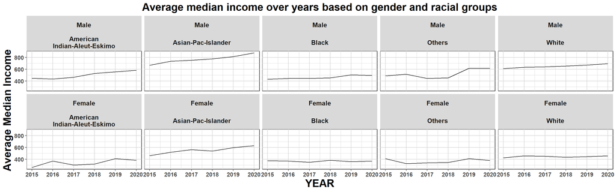

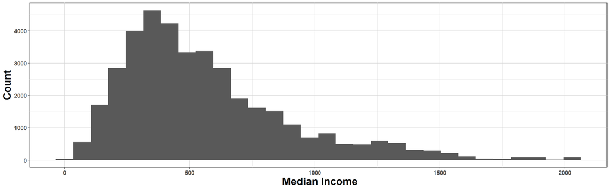

We found that the median income is skewed in the wrong direction. We fit a linear model to revenue after applying a log transformation to make it normally distributed. With log converted income data, we found a considerable improvement in the model. # Log transform the median income

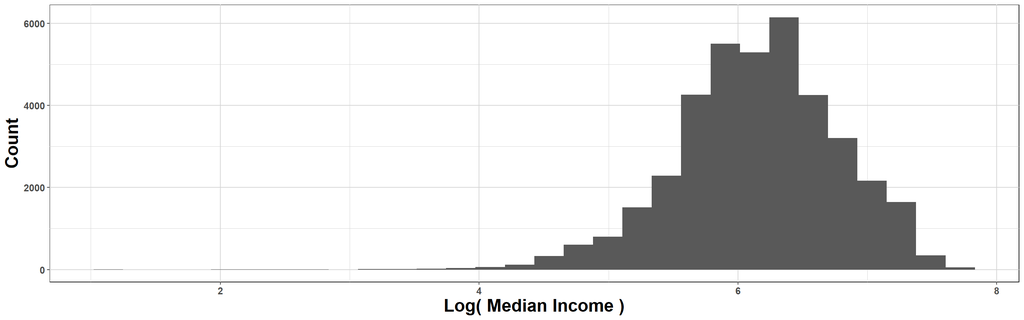

# 3. Fit a model to predictive median income of a person based on year, gender, race group, education group, major industry and age group

# Trying to fit a lm

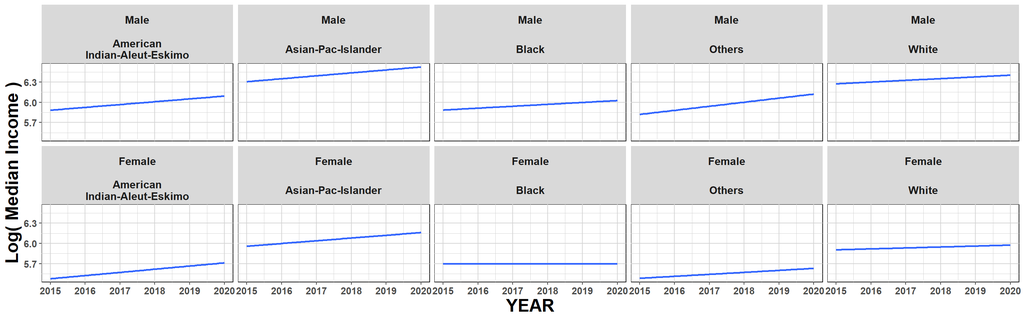

```
[1] 30511.6
```

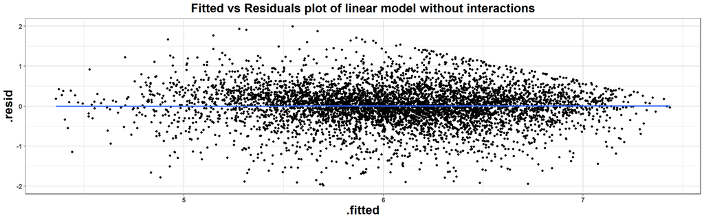

# 4. Does interactions improves the model.

### Check if Major Industry and Race Group interact

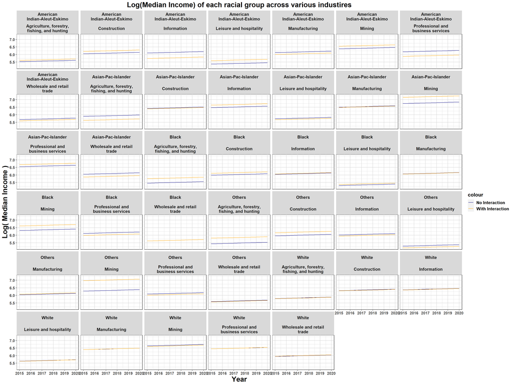

From the above plot, we see that Major Industry and Race does have an interaction and adding it to our model should be helpful.

### Check if Major Industry and Gender interact

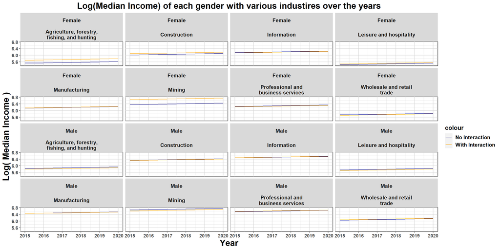

There is a significant interaction between gender and major industry, and hence we will add this to our model.

### Check if Age Groups and Gender intracts

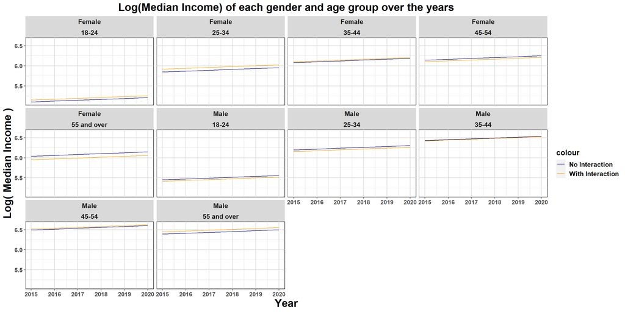

Gender and age group do interact and hence should be beneficial to consider this in our model.